# Project 1

Mary de Boer

2024-09-12

## Step 1

I downloaded the Chocolate data and loaded into R; I then constructed four histograms of the chocolate ratings (on a scale of 1.0 to 4.0), varying the number of bins from the 10 to 25. These four histograms are depicted below.

[figure not shown]

```r
par(mfrow = c(2, 2))
hist(chocolate$rating, breaks = 10, main = "Histogram of Chocolate Ratings \n with 10 Bins",
     xlab = "Rating")
hist(chocolate$rating, breaks = 15, main = "Histogram of Chocolate Ratings \n with 15 Bins",
     xlab = "Rating")
hist(chocolate$rating, breaks = 20, main = "Histogram of Chocolate Ratings \n with 20 Bins",
     xlab = "Rating")
hist(chocolate$rating, breaks = 25, main = "Histogram of Chocolate Ratings \n with 10 Bins",
     xlab = "Rating")
```

I ultimately chose the histogram with 10 bins, as this was a smooth histogram without any breaks in the data. It also felt most representative of the natural breaks one might expect in the rating data – going up by increments of 0.5.

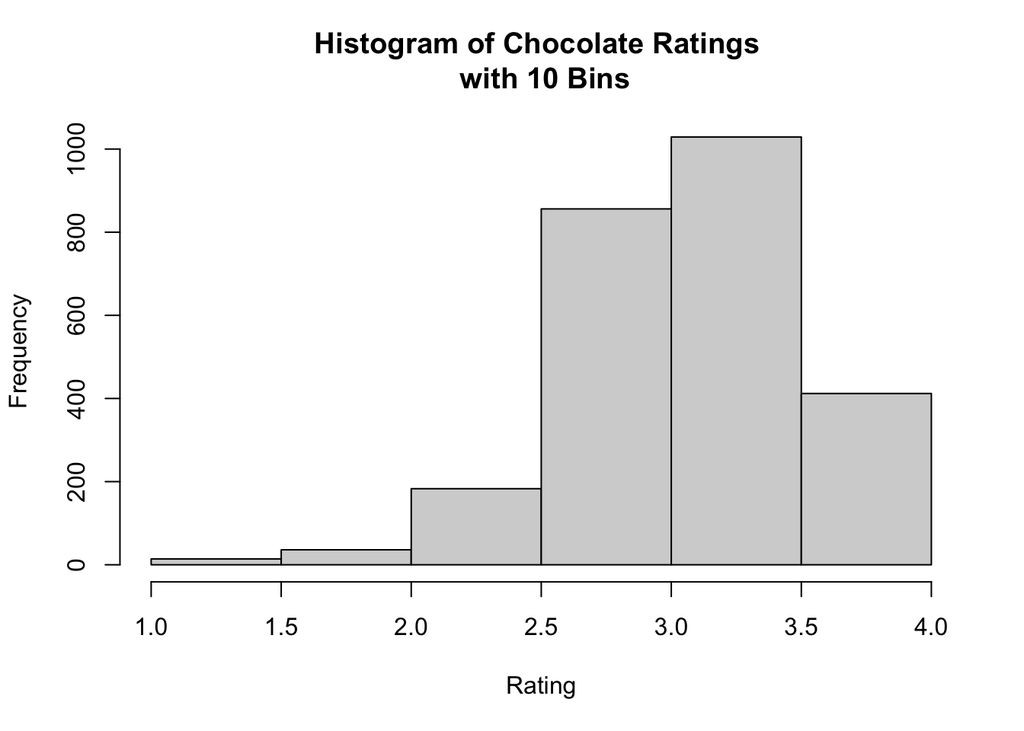

```r
par(mfrow = c(1, 1))
hist(chocolate$rating, breaks = 10, main = "Histogram of Chocolate Ratings \n with 10 Bins",
     xlab = "Rating")
```

## Step 2

Considering the countries of bean origin, the number of reviews varies widely:

```r
chocolate %>% group_by(country_of_bean_origin) %>% summarize(num_reviews = length(rating))
```

```
## # A tibble: 62 × 2
##    country_of_bean_origin num_reviews
##    <chr>                        <int>
##  1 Australia                        3
##  2 Belize                          76
##  3 Blend                          156
##  4 Bolivia                         80
##  5 Brazil                          78
##  6 Burma                            1
##  7 Cameroon                         3
##  8 China                            1
##  9 Colombia                        79
## 10 Congo                           11
## # ℹ 52 more rows
```

## Step 3

The average rating for chocolate originating in Ecuador is presented below, along with the total number of reviews and the standard deviation of the rating scores.

```r
ecuador <- chocolate %>% filter(country_of_bean_origin == "Ecuador") %>% summarize(mean= mean(rating), sd = sd(rating), total = length(rating))
ecuador
```

```
## # A tibble: 1 × 3
##    mean    sd total
##   <dbl> <dbl> <int>
## 1  3.16 0.512   219
```

## Step 4

The following three manufacturers make the best chocolate (ie. have the highest ratings on average) with beans from Ecuador:

```r
head(chocolate %>% filter(country_of_bean_origin == "Ecuador") %>% group_by(company_manufacturer) %>% summarize(mean = mean(rating)) %>% arrange(desc(mean)), 3)
```

```
## # A tibble: 3 × 2
##   company_manufacturer  mean
##   <chr>                <dbl>
## 1 Amano                    4
## 2 Benoit Nihant            4
## 3 Beschle (Felchlin)       4
```

## Step 5

The top 3 countries (for bean origin) in terms of highest average ratings are:

```r
head(chocolate %>% group_by(country_of_bean_origin) %>%summarize(mean= mean(rating)) %>% arrange(desc(mean)), 3)
```

```
## # A tibble: 3 × 2
##   country_of_bean_origin  mean
##   <chr>                  <dbl>
## 1 Tobago                  3.62
## 2 China                   3.5
## 3 Sao Tome & Principe     3.5
```

## Step 6

Next, I filtered countries of bean origin that had less than 10 chocolate reviews. The top 3 countries with the highest ratings on average were:

```r
head(chocolate %>% group_by(country_of_bean_origin) %>% filter(length(ref) >=10) %>% summarize(mean= mean(rating)) %>% arrange(desc(mean)), 3)
```

```
## # A tibble: 3 × 2
##   country_of_bean_origin  mean
##   <chr>                  <dbl>
## 1 Solomon Islands         3.45
## 2 Congo                   3.32
## 3 Cuba                    3.29
```

## Step 7

For this part, I removed countries with less than 50 reviews Then, I created a new column grouping chocolate percentages into one of four groups: (i) <60%, (ii) >=60 to <70%, (iii) >=70 to <90%, and (iii) >=90%. Using this new column, I generated side-by-side boxplots with the groups on the x-axis and the ratings on the y-axis, faceted by country.

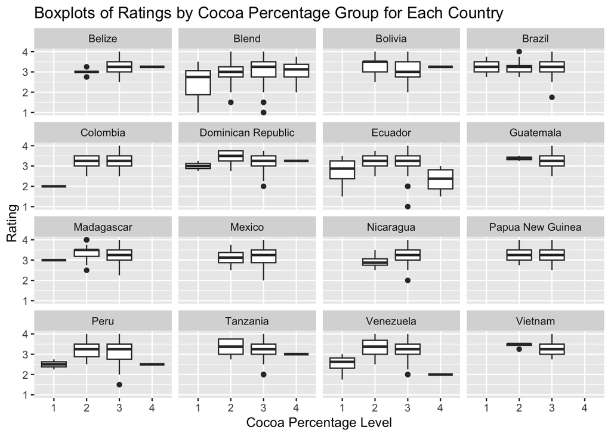

```r
#Identify the countries of bean origin with at least 50 reviews. Remove reviews from countries are not in this list.

chocplus50 <- chocolate%>% group_by(country_of_bean_origin) %>%
  summarize(review_num=length(ref)) %>%
  filter(review_num>=50)

#Using the variable describing the chocolate percentage for each review, create a new column that groups chocolate percentages
#into one of four groups: (i) <60%, (ii) >=60 to <70%, (iii) >=70 to <90%, and
#(iii) >=90% (Hint check out the substr() function in base R and the case_when() function from dplyr – see example below).

chocplus50 <- right_join(chocolate, chocplus50, by = "country_of_bean_origin")

chocplus50 <- chocplus50 %>% mutate(chocpercent = case_when(
  cocoa_percent <"60%" ~ 1,
  cocoa_percent >= "60%" & cocoa_percent < "70%" ~ 2,
  cocoa_percent >= "70%" & cocoa_percent < "90%" ~ 3,
  cocoa_percent >= "90%" ~ 4
))
#don't need to relevel but making a factor column
chocplus50$chocpercent <- factor(chocplus50$chocpercent, levels = c(1, 2, 3, 4))

#For each country, make a set of four side-by-side boxplots plotting the groups on the x-axis and the
#ratings on the y-axis. These plots should be faceted by country
ggplot(chocplus50, aes(x = chocpercent, y = rating)) +
  geom_boxplot() +
  facet_wrap(~ country_of_bean_origin) +  # Adjust scales if needed
  labs(x = "Cocoa Percentage Level", y = "Rating", title = "Boxplots of Ratings by Cocoa Percentage Group for Each Country")
```

Based on these data, category #2 (60-70% cocoa) is on average the most highly rated chocolate category.

```r
chocplus50 %>% group_by(chocpercent) %>% summarize(mean_rating = mean(rating))
```

```
## # A tibble: 4 × 2
##   chocpercent mean_rating
##   <fct>             <dbl>
## 1 1                  2.67
## 2 2                  3.25
## 3 3                  3.22
## 4 4                  2.75
```

Based on the box plot above, this seems to be relatively in agreement across the different countries, with levels 2 and 3 higher than 1 or 4. In a few places – Mexico, Nicaragua, PNG, and Vietnam, for example, there are no other categories of cocoa percentage other than 2 or 3. In Belize, the Blend category, Mexico, and Nicaragua, it appears that level 3 is more preferred. This small difference between the two categories is represented in the very small different (0.03 points) between the average rating of the level 3 and 3 cocoa percent groups.

# Part 2

Merging the gapminder and chocolate datasets, I added a column that contains the continent name for the the country of bean origin for each review. I also filtered for countries with at least 10 reviews, made sure there were no missing continents for any of the countries, and removed the country of bean origin named “Blend”.

```r
gapminder_unique <- gapminder %>%
  group_by(country) %>%
  summarize(continent = first(continent))

chocolate_data <- chocolate %>%
  left_join(gapminder_unique, by = c("country_of_bean_origin" = "country"))


chocplus10 <- chocolate_data%>% group_by(country_of_bean_origin) %>%
  summarize(review_num=n()) %>%
  filter(review_num>=10)

chocplus.10 <- inner_join(chocolate_data, chocplus10, by = "country_of_bean_origin")
chocplus.10 <- filter(chocplus.10, country_of_bean_origin != "Blend")
na_check <- chocplus.10 %>%
  filter(is.na(continent))

continent_data <- tibble(
  country_of_bean_origin = unique(na_check$country_of_bean_origin),
  continent = c("Oceania", "Oceania", "Africa", "Oceania", "South America",
                "North America", "North America", "Africa", "Oceania",
                "North America", "North America")
)

chocplus_10 <- left_join(chocplus.10, continent_data, by="country_of_bean_origin") %>%
  mutate(continent = coalesce(continent.x, continent.y)) %>%
  select(-continent.x, -continent.y)

names(chocplus_10)
```

```
##  [1] "ref"                              "company_manufacturer"
##  [3] "company_location"                 "review_date"
##  [5] "country_of_bean_origin"           "specific_bean_origin_or_bar_name"
##  [7] "cocoa_percent"                    "ingredients"
##  [9] "most_memorable_characteristics"   "rating"
## [11] "review_num"                       "continent"
```

Finally, I made a set of violin plots with ratings on the y-axis and continents on the x-axis.

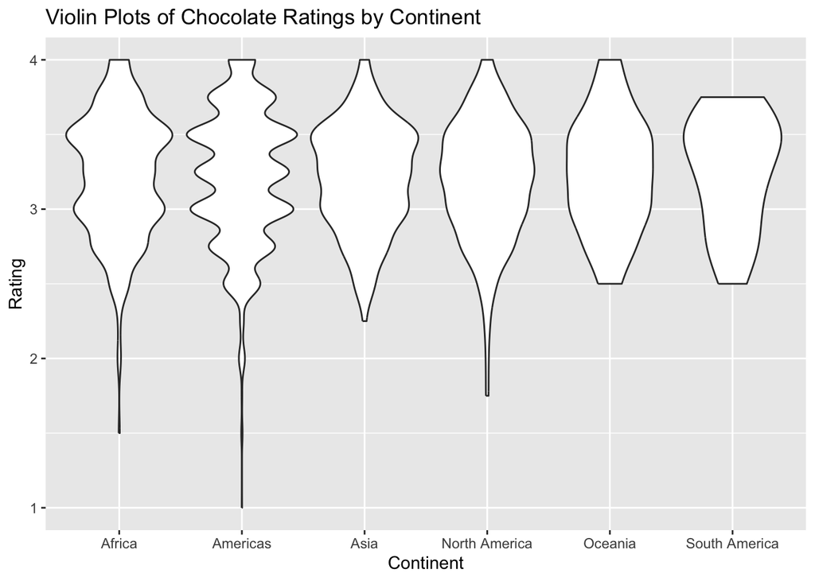

```r
ggplot(chocplus_10, aes(x = continent, y = rating)) +
  geom_violin()+
  labs(x = "Continent", y = "Rating", title = "Violin Plots of Chocolate Ratings by Continent")
```

# Part 3

In this part, I created new columns for the ingredients and memorable characteristics.

```r
chocplus_10<- chocplus_10 %>%
  mutate(
    beans = if_else(str_detect(ingredients, "B"), 1, 0),
    sugar = if_else(str_detect(ingredients, "S"), 1, 0),
    cocoa_butter = if_else(str_detect(ingredients, "C"), 1, 0),
    vanilla = if_else(str_detect(ingredients, "V"), 1, 0),
    lecthin = if_else(str_detect(ingredients, "L"), 1, 0),
    salt = if_else(str_detect(ingredients, "Sa"), 1, 0)
  )

chocplus_10<- chocplus_10 %>%
  mutate(
    char_cocoa = if_else(str_detect(most_memorable_characteristics, "cocoa"), 1, 0),
    char_sweet = if_else(str_detect(most_memorable_characteristics, "sweet"), 1, 0),
    char_nutty = if_else(str_detect(most_memorable_characteristics, "nutty"), 1, 0),
    char_creamy = if_else(str_detect(most_memorable_characteristics, "creamy"), 1, 0),
    char_roasty = if_else(str_detect(most_memorable_characteristics, "roasty"), 1, 0),
    char_earthy = if_else(str_detect(most_memorable_characteristics, "earthy"), 1, 0)
  )
names(chocplus_10)
```

```
##  [1] "ref"                              "company_manufacturer"
##  [3] "company_location"                 "review_date"
##  [5] "country_of_bean_origin"           "specific_bean_origin_or_bar_name"
##  [7] "cocoa_percent"                    "ingredients"
##  [9] "most_memorable_characteristics"   "rating"
## [11] "review_num"                       "continent"
## [13] "beans"                            "sugar"
## [15] "cocoa_butter"                     "vanilla"
## [17] "lecthin"                          "salt"
## [19] "char_cocoa"                       "char_sweet"
## [21] "char_nutty"                       "char_creamy"
## [23] "char_roasty"                      "char_earthy"
```

```r
#
```

```r
# Calculate mean values by year
choc_reviews<- chocplus_10 %>%
  group_by(review_date) %>%
  summarize(across(c("beans", "sugar", "cocoa_butter", "vanilla",
                                 "lecthin", "salt", "char_cocoa", "char_sweet",
                                 "char_nutty", "char_creamy", "char_roasty",
                                 "char_earthy"),  ~ mean(.x, na.rm = TRUE)))

choc_long <- choc_reviews %>%
  pivot_longer(cols = c("beans", "sugar", "cocoa_butter", "vanilla",
                        "lecthin", "salt", "char_cocoa", "char_sweet",
                        "char_nutty", "char_creamy", "char_roasty",
                        "char_earthy"),
               names_to = "feature",
               values_to = "mean_score")

head(choc_long)
```

```
## # A tibble: 6 × 3
##   review_date feature      mean_score
##         <dbl> <chr>             <dbl>
## 1        2006 beans             1
## 2        2006 sugar             1
## 3        2006 cocoa_butter      0.925
## 4        2006 vanilla           0.7
## 5        2006 lecthin           0.725
## 6        2006 salt              0
```

# Part 4

I then produced a scatterplot of the mean_scores (y-axis) over time (x-axis) with one plot (facet) for each ingredient/characteristic feature.

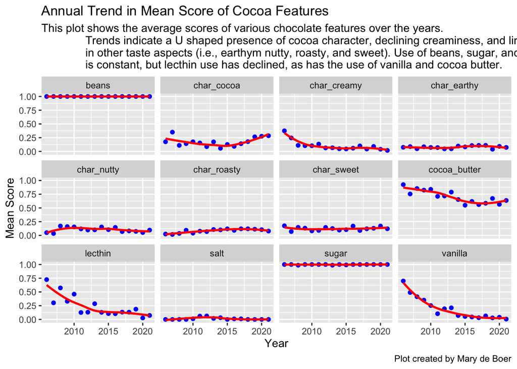

```r
ggplot(choc_long, aes(x = review_date, y = mean_score)) +
  geom_point(color = "blue") +  # Add scatter points
  geom_smooth(method = "loess", color = "red", se = FALSE) +
         facet_wrap(~ feature) +
         labs(x = "Year", y = "Mean Score",
              title = "Annual Trend in Mean Score of Cocoa Features",
              subtitle = "This plot shows the average scores of various chocolate features over the years.
              Trends indicate a U shaped presence of cocoa character, declining creaminess, and limited change
              in other taste aspects (i.e., earthym nutty, roasty, and sweet). Use of beans, sugar, and salt
              is constant, but lecthin use has declined, as has the use of vanilla and cocoa butter.",
              caption = "Plot created by Mary de Boer")
```

# Part 5

I did not have time to do this.

# Part 6

I improved the plot in the following ways: 1. I made the fill meaningful. Now, each violin is filled according to cocoa percentage, which is a factor rather than a gradient – fill by year as a continuous variable had no meaning.

2. I faceted by year in order to better visualize the annual trends.
3. I added a legend with labels. The legend should be clear and linked to what is depicted in the plot.
4. I defined the legend labels in the subtitle. This makes the values of the levels clear.
5. I added x and y axis titles. Without these, the viewer cannot interpret the data.
6. I included a title for the plot. This helps prepare viewers for what will be included in the plot.
7. I explained authorship at the bottom. This prevents plagiarism.

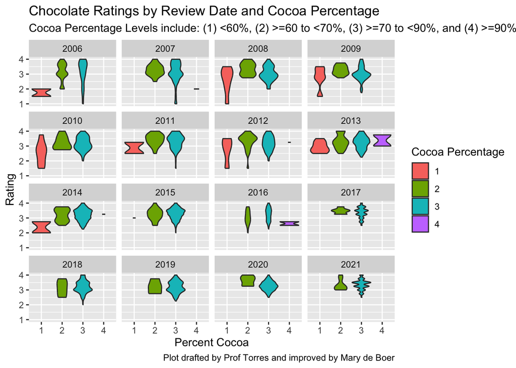

```r
chocplus50 %>%
  ggplot(aes(
   x = (chocpercent),
    y = rating,
    fill =chocpercent
  )) +
  geom_violin() +
  facet_wrap(~review_date) +
  ggtitle("Chocolate Ratings by Review Date and Cocoa Percentage") +
  labs(x = "Percent Cocoa", y = "Rating", fill = "Cocoa Percentage",
       subtitle= "Cocoa Percentage Levels include: (1) <60%, (2) >=60 to <70%, (3) >=70 to <90%, and (4) >=90%",
       caption = "Plot drafted by Prof Torres and improved by Mary de Boer")
```